# Progetto Metodi finanziari

Francesco_Gabellini

2018-05-24

## File con i passaggi per analisi su start up

Unica modifica effettuata su excel è stato riscrivere i nomi delle variabili in formato s_n_a_k_e

## Manipolazioni sul dataset

Apro librerie necessarie e setto la casualità per ottenere stessi risultati su più macchine

```r
library(tidyverse)
library(readxl)
library(caret)
set.seed(1234)
```

Importo dati da excel

```r
DS <- read_excel("C:/Users/SuperOrso1/Desktop/Metodi finanziari/Progetto/dataset_fb03.xlsx")
```

Elimino le non start up

```r
DS_1 <- DS %>%
        filter (Startup_dummy=="si")
```

Elimino chi non ha almeno un si nei requisiti

```r
DS_1 <- DS_1 %>%
        filter (req_1=="SI"|req_2=="SI"|req_3=="SI")
```

Seleziono le variabili di mio interesse

```r
DS_2 <- DS_1 %>%
        select (Nome,Data_bilancio,ROA,EBITDAmarg,RotazCapInv,IndiIndipFin,IndCorr,
                Sede_Longitudine,Sede_Latitudine,Website,ATECO_codice,Dipendenti,Data_creazione,
                PrevFemm_red,PrevGiov_red,Sede_regione,Stato_giuridico,Indipendenza_BvD,N_partecipate,Macroregione_SupCor,Macroregione_NUTS,Sede_provincia,req_1,req_2,req_3)
```

Voglio solo chi ha nel bilancio 2016 Quindi prima scompongo data poi tengo solo i 2016

```r
DS_3 <- DS_2 %>%
        separate("Data_bilancio", c("Anno", "Mese", "Giorno"), sep = "-")
DS_3 <- DS_3 %>%
        filter(Anno=="2016")
```

Scompongo data di creazione

```r
DS_3 <- DS_3 %>%
        separate("Data_creazione", c("Anno_c", "Mese_c", "Giorno_c"), sep = "-")
DS_4 <-DS_3
```

Impunto gli NA nei valori numerici

```r
DS_4 <-  DS_4 %>%
        select (Nome,ROA,EBITDAmarg,RotazCapInv,IndiIndipFin,IndCorr,Dipendenti,PrevFemm_red,PrevGiov_red,Stato_giuridico)

dummy.vars <- dummyVars(~. , data = DS_4[,-1])
train.dummy <- predict(dummy.vars, DS_4[,-1])
train.dummy <- as.data.frame(train.dummy)
colnames(train.dummy)[12] <- "Attiva"
pre.process <- preProcess(train.dummy, method = "bagImpute")
imputed.data <- predict(pre.process, train.dummy)
```

Reinserisco i valori imputati nel mio dataset iniziale

```r
DS_3$EBITDAmarg <-imputed.data$EBITDAmarg
DS_3$ROA <- imputed.data$ROA
DS_3$RotazCapInv <- imputed.data$RotazCapInv
DS_3$IndCorr <- imputed.data$IndCorr
DS_4 <- na.omit(DS_3)
```

Guardo settore informatico ateco 62:

Prendo solo primi 2 numeri codice ateco

```r
DS_4$Ateco_2 <- substr(DS_4$ATECO_codice, start = 1, stop = 2)
```

Ora creo dummy

```r
DS_4$informatica <- as.numeric(DS_4$Ateco_2 == 62)
```

guardo quanti sono

```r
DS_4$informatica <- as.factor(DS_4$informatica)
DS_4 %>%
    count(informatica)
```

```
## # A tibble: 2 x 2
##   informatica     n
##   <fct>       <int>
## 1 0            1981
## 2 1             899
```

Seleziono solo aziende informatiche

```r
DS_4<-    DS_4 %>%
          filter(informatica==1)
```

## Controllo e pulizia dataset

Inizio con roa

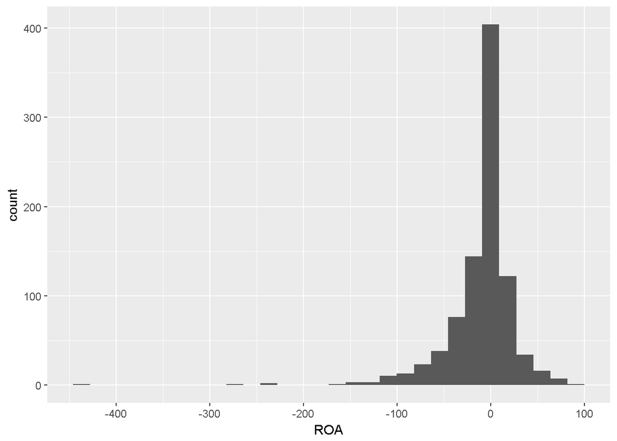

```r
ggplot(data=DS_4,
       mapping=aes(x=ROA))+
geom_histogram()
```

```r
summary(DS_4$ROA)
```

```
##     Min.  1st Qu.   Median     Mean  3rd Qu.     Max.
## -438.120  -18.330   -0.690   -9.233    5.920   89.920
```

```r
quantile(DS_4$ROA,0.01)
```

```
##       1%
## -125.072
```

Guardo rotazione capitale investito

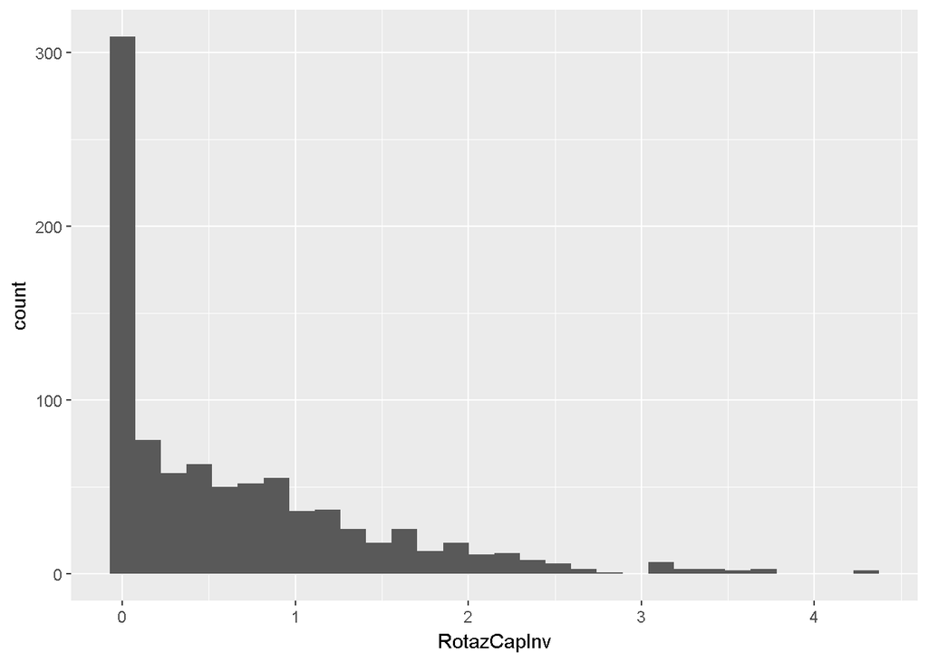

```r
ggplot(data=DS_4,
       mapping=aes(x=RotazCapInv))+
geom_histogram()
```

```r
summary(DS_4$RotazCapInv)
```

```
##    Min. 1st Qu.  Median    Mean 3rd Qu.    Max.
##  0.0000  0.0000  0.3800  0.6452  1.0100  4.3000
```

guardo ebitda margin

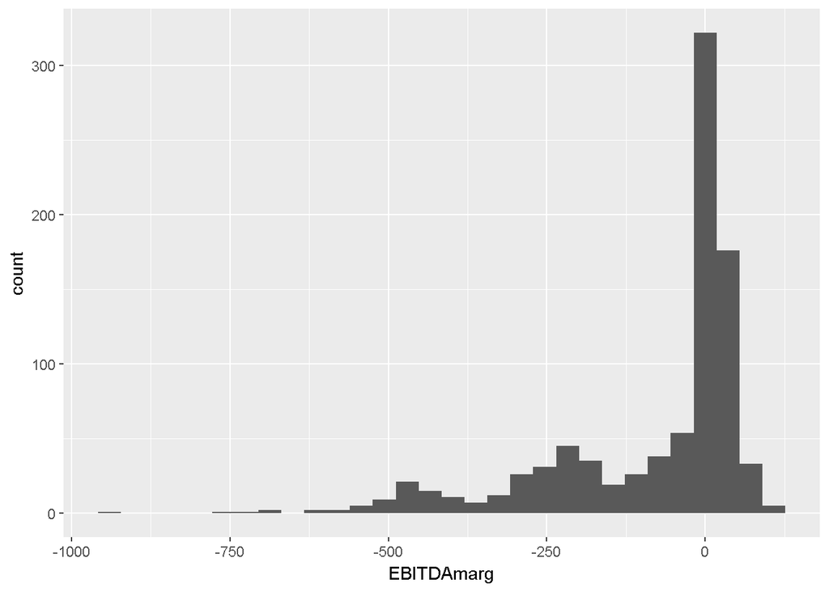

```r
ggplot(data=DS_4,
       mapping=aes(x=EBITDAmarg))+
geom_histogram()
```

```r
summary(DS_4$EBITDAmarg)
```

```
##    Min. 1st Qu.  Median    Mean 3rd Qu.    Max.
## -949.17 -167.57    1.99  -81.01   17.30   99.85
```

```r
quantile(DS_4$EBITDAmarg,0.01)
```

```
##        1%
## -558.1849
```

taglio - 500 e vedo come viene

```r
DS_5 <- DS_4 %>%
       filter(EBITDAmarg>-500)
```

guardo indice indipendenza finanziaria

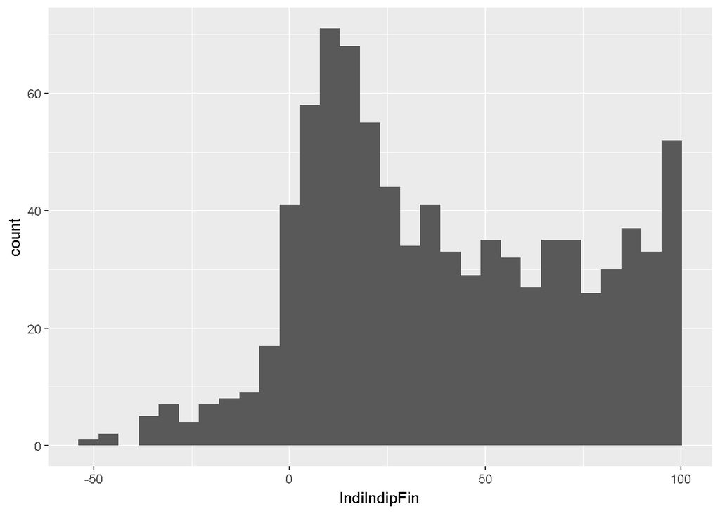

```r
ggplot(data=DS_5,
       mapping=aes(x=IndiIndipFin))+
geom_histogram()
```

```r
summary(DS_4$IndiIndipFin)
```

```
##    Min. 1st Qu.  Median    Mean 3rd Qu.    Max.
##  -49.03   12.26   34.96   40.04   69.64  100.00
```

guardo corrente

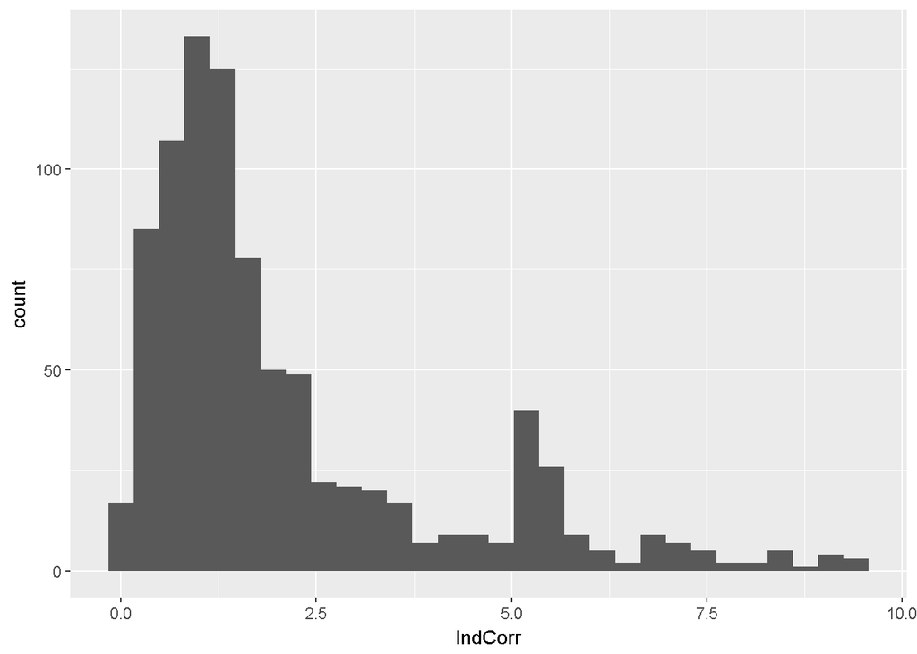

```r
ggplot(data=DS_5,
       mapping=aes(x=IndCorr))+
geom_histogram()
```

```r
summary(DS_4$IndCorr)
```

```
##    Min. 1st Qu.  Median    Mean 3rd Qu.    Max.
##   0.030   0.860   1.392   2.162   2.765   9.440
```

mancano varianza da summary

```r
var(DS_4$ROA)
```

```
## [1] 1355.425
```

```r
var(DS_4$EBITDAmarg)
```

```
## [1] 25215.57
```

```r
var(DS_4$IndCorr)
```

```
## [1] 3.906833
```

```r
var(DS_4$IndiIndipFin )
```

```
## [1] 1170.784
```

```r
var(DS_4$RotazCapInv )
```

```
## [1] 0.6053762
```

## mappare sull’italia

Mappa regioni per start-up

Apro library

```r
library(devtools)
install_github("nicolasturaro/mapIT")
library(mapIT)
```

Creo data frame per regioni

```r
DS_regio <-DS_5 %>%
          select(Nome,Dipendenti,Sede_regione)
DS_regio <- na.omit(DS_regio)
DS_regio_1<- DS_regio %>%
             count(Sede_regione)

DS_regio_1$Sede_regione[DS_regio_1$Sede_regione == "Valle d'Aosta/Vallée d'Aoste"] <- "Valle d'Aosta"
DS_regio_1 <- as.data.frame(DS_regio_1)
```

Creo mappa start up per regioni

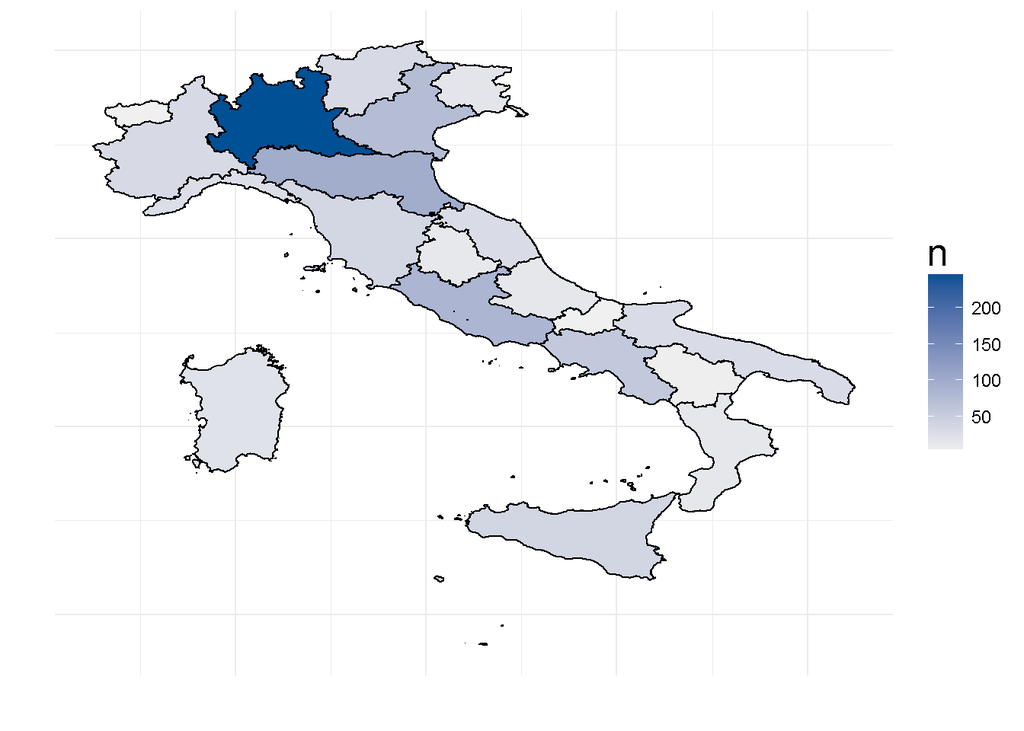

```r
mapIT(n, Sede_regione, data=DS_regio_1)
```

## Inizio analisi componenti principali dopo pulizia

library componenti principali

```r
dati<-as.data.frame(DS_5)
```

```r
library(Rcmdr)
library(psych)
```

```r
library(FactoMineR)
```

PCA su factoMineR

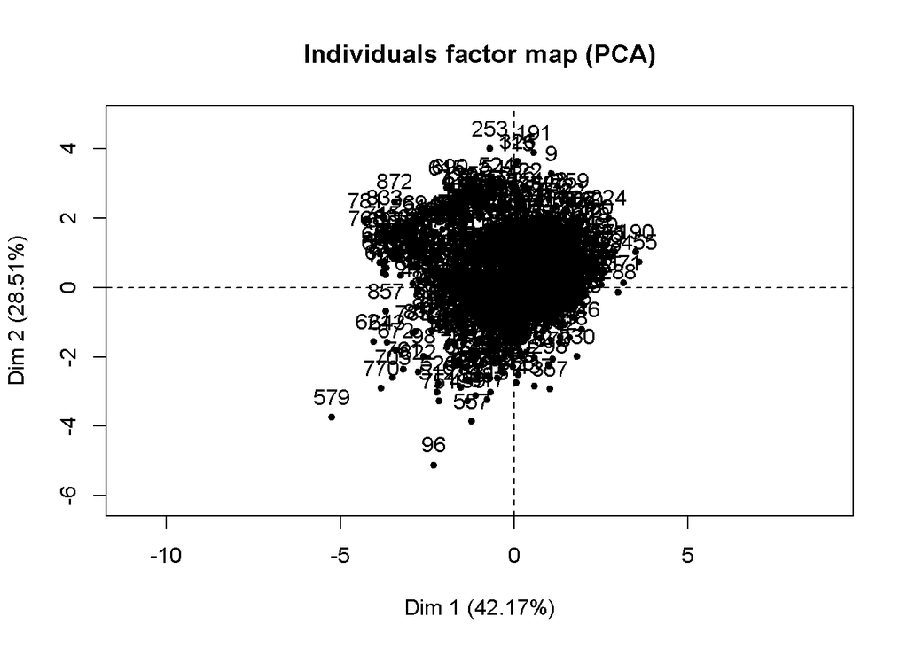

```r
dati.PCA<-dati[, c("ROA", "EBITDAmarg", "RotazCapInv", "IndiIndipFin",
  "IndCorr")]
res<-PCA(dati.PCA , scale.unit=TRUE, ncp=5, graph = FALSE)
plot.PCA(res, axes=c(1, 2), choix="ind", habillage="none", col.ind="black",
  col.ind.sup="blue", col.quali="magenta", label=c("ind", "ind.sup", "quali"),
  new.plot=TRUE)
```

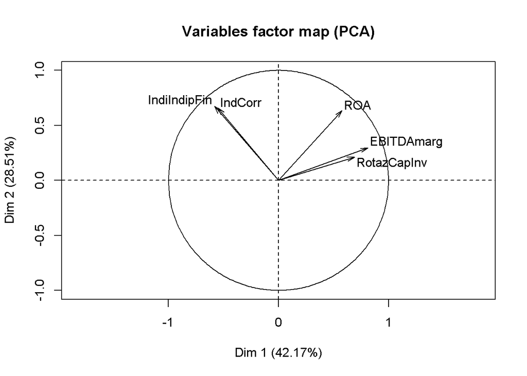

```r
plot.PCA(res, axes=c(1, 2), choix="var", new.plot=TRUE, col.var="black",
  col.quanti.sup="blue", label=c("var", "quanti.sup"), lim.cos2.var=0)
```

```r
summary(res, nb.dec = 3, nbelements=10, nbind = 10, ncp = 3, file="")
```

```
##
## Call:
## PCA(X = dati.PCA, scale.unit = TRUE, ncp = 5, graph = FALSE)
##
##
## Eigenvalues
##                        Dim.1   Dim.2   Dim.3   Dim.4   Dim.5
## Variance               2.109   1.426   0.660   0.464   0.342
## % of var.             42.173  28.513  13.194   9.284   6.837
## Cumulative % of var.  42.173  70.686  83.880  93.163 100.000
##
## Individuals (the 10 first)
##                  Dist    Dim.1    ctr   cos2    Dim.2    ctr   cos2
## 1            |  1.322 |  1.296  0.091  0.961 | -0.015  0.000  0.000 |
## 2            |  1.193 |  1.052  0.060  0.778 |  0.091  0.001  0.006 |
## 3            |  1.607 | -0.697  0.026  0.188 |  0.821  0.054  0.261 |
## 4            |  1.399 |  1.283  0.089  0.840 | -0.514  0.021  0.135 |
## 5            |  2.215 |  1.510  0.123  0.465 |  0.824  0.054  0.138 |
## 6            |  2.904 | -1.487  0.120  0.262 |  2.055  0.338  0.501 |
## 7            |  1.036 |  0.815  0.036  0.618 | -0.563  0.025  0.295 |
## 8            |  2.014 |  1.457  0.115  0.523 | -1.078  0.093  0.287 |
## 9            |  3.681 |  1.064  0.061  0.084 |  3.272  0.857  0.790 |
## 10           |  2.150 |  1.888  0.193  0.771 | -0.181  0.003  0.007 |
##               Dim.3    ctr   cos2
## 1            -0.143  0.004  0.012 |
## 2             0.441  0.034  0.137 |
## 3            -0.651  0.073  0.164 |
## 4            -0.055  0.001  0.002 |
## 5             1.361  0.321  0.377 |
## 6             0.761  0.100  0.069 |
## 7            -0.236  0.010  0.052 |
## 8             0.665  0.076  0.109 |
## 9             1.245  0.268  0.114 |
## 10            0.943  0.154  0.192 |
##
## Variables
##                 Dim.1    ctr   cos2    Dim.2    ctr   cos2    Dim.3    ctr
## ROA          |  0.578 15.826  0.334 |  0.635 28.314  0.404 | -0.362 19.913
## EBITDAmarg   |  0.812 31.251  0.659 |  0.296  6.165  0.088 | -0.173  4.525
## RotazCapInv  |  0.690 22.560  0.476 |  0.213  3.170  0.045 |  0.674 68.875
## IndiIndipFin | -0.580 15.962  0.337 |  0.673 31.746  0.453 | -0.001  0.000
## IndCorr      | -0.551 14.401  0.304 |  0.661 30.605  0.436 |  0.210  6.687
##                cos2
## ROA           0.131 |
## EBITDAmarg    0.030 |
## RotazCapInv   0.454 |
## IndiIndipFin  0.000 |
## IndCorr       0.044 |
```

```r
remove(dati.PCA)
```

Ruoto le componenti principali per dargli un significato al meglio tramite altro pacchetto

```r
data_rot<-subset(dati, select = c(ROA,EBITDAmarg, RotazCapInv, IndiIndipFin, IndCorr))
ro<-principal(data_rot,nfactors=2,rotate = "varimax", scores = T)
ro
```

```
## Principal Components Analysis
## Call: principal(r = data_rot, nfactors = 2, rotate = "varimax", scores = T)
## Standardized loadings (pattern matrix) based upon correlation matrix
##                RC1   RC2   h2   u2 com
## ROA           0.84  0.19 0.74 0.26 1.1
## EBITDAmarg    0.84 -0.22 0.75 0.25 1.1
## RotazCapInv   0.69 -0.22 0.52 0.48 1.2
## IndiIndipFin -0.09  0.88 0.79 0.21 1.0
## IndCorr      -0.08  0.86 0.74 0.26 1.0
##
##                        RC1  RC2
## SS loadings           1.89 1.65
## Proportion Var        0.38 0.33
## Cumulative Var        0.38 0.71
## Proportion Explained  0.53 0.47
## Cumulative Proportion 0.53 1.00
##
## Mean item complexity =  1.1
## Test of the hypothesis that 2 components are sufficient.
##
## The root mean square of the residuals (RMSR) is  0.12
##  with the empirical chi square  256.55  with prob <  9.7e-58
##
## Fit based upon off diagonal values = 0.87
```

Si evidenziano 2 componenti principali una correlata con la redditività e una con la solidità patrimoniale

Creo nuovo dataframe con le prime 2 componenti principali

```r
Dati_pca <- ro$scores
Dati_pca <- as.data.frame(Dati_pca)
```

Ora faccio mappa fattoriale degli individui

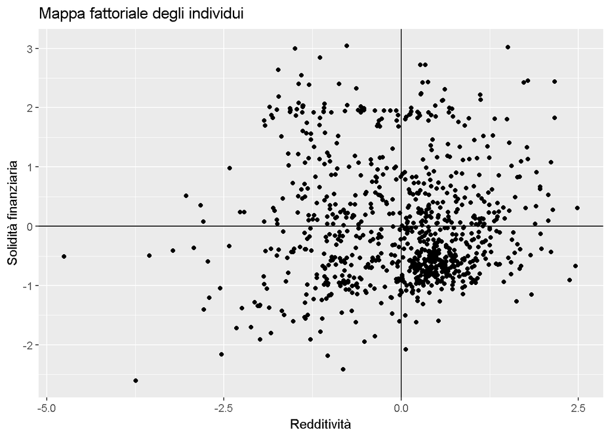

```r
ggplot(data=Dati_pca)+
      geom_point(mapping = aes(x=RC1,y=RC2))+
      geom_hline(yintercept = 0)+
      geom_vline(xintercept = 0)+
      xlab("Redditività")+
      ylab("Solidità finanziaria")+
      labs(title = "Mappa fattoriale degli individui")
```

Validazione empirica

```r
v <- NULL
for(i in 1:1000){
a1 <- rnorm(632)
a2 <- rnorm(632)
a3 <- rnorm(632)
a4 <- rnorm(632)
a5 <- rnorm(632)
df <- data.frame(a1,a2,a3,a4,a5)
pca_dati <- PCA(df,graph = F)
a <- pca_dati$eig[2,3]
v <- c(v,a)

}
```

Ad ogni passaggio in v viene inserito un valore a e poi riassegnando allo stesso nome posso mantenere in memoria tutti gli a gia aggiunti e ad ogni passaggio aggiungo il nuovo valore di a.

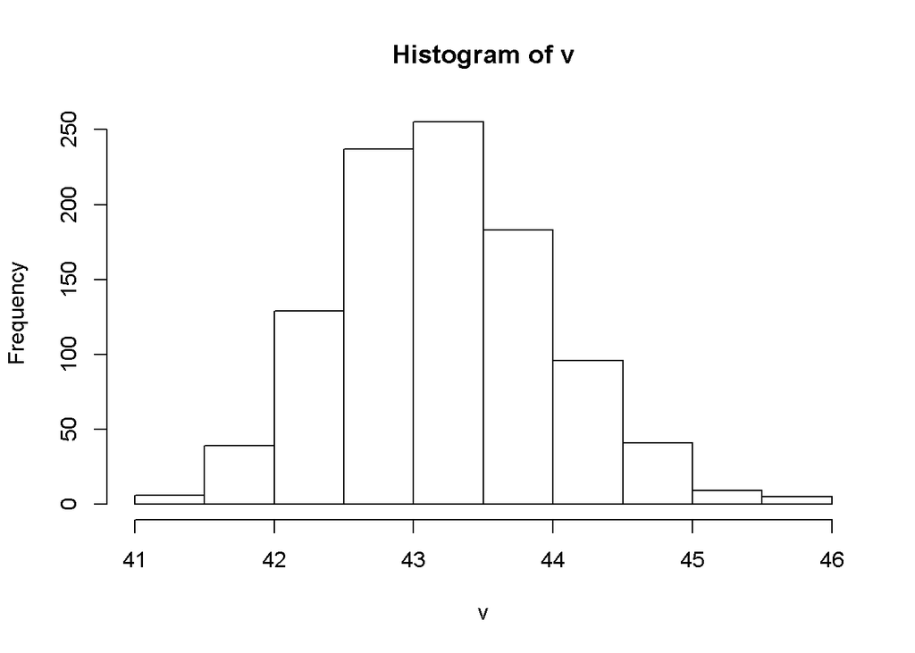

```r
hist(v)
```

```r
quantile(v,0.95)
```

```
##     95%
## 44.5331
```

```r
summary(v)
```

```
##    Min. 1st Qu.  Median    Mean 3rd Qu.    Max.
##   41.26   42.71   43.16   43.21   43.71   45.78
```

Quindi il nostro risultato non è casuale

Metto componenti principali nel dataset con le altre variabili

```r
dati_finali<-cbind.data.frame(dati,Dati_pca)
```

Mappa fattoriale individui per prevalenze

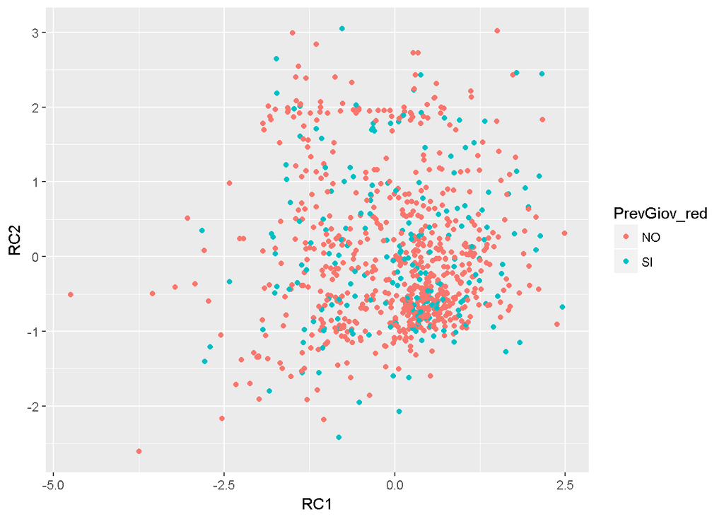

```r
ggplot(data= dati_finali)+
      geom_point(mapping = aes(x=RC1,y=RC2,color=PrevGiov_red))
```

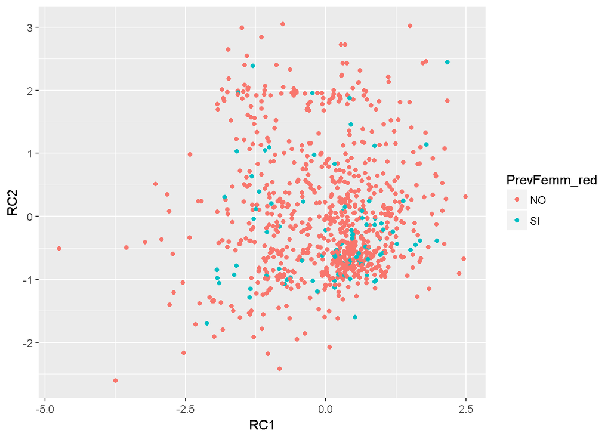

```r
ggplot(data= dati_finali)+
      geom_point(mapping = aes(x=RC1,y=RC2,color=PrevFemm_red))
```

Non sembrano essere discriminanti

## Analisi dei gruppi su componenti principali

Faccio su Rcmdr

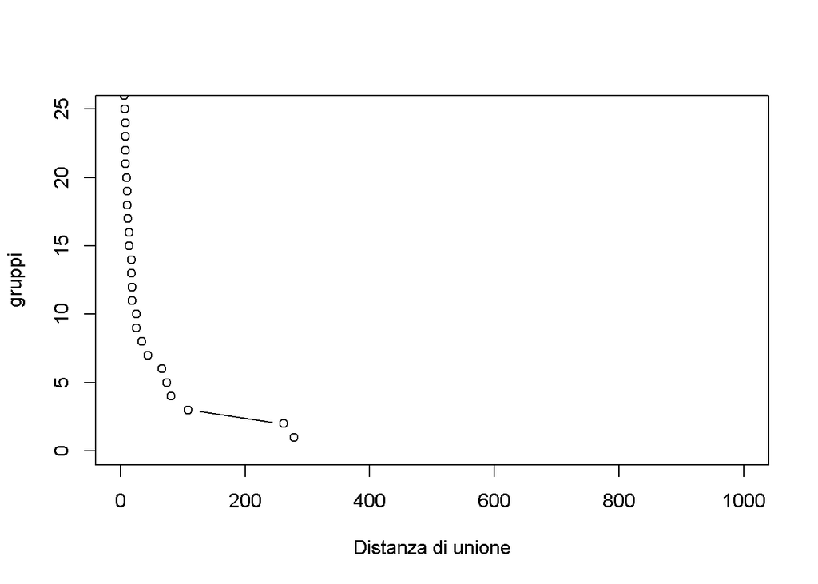

```r
gruppi<-875:1
Hc_dati <- hclust(dist(model.matrix(~-1 +
  RC1+RC2, dati_finali)) , method=
  "ward")
plot(Hc_dati$height,gruppi,type="b",xlab = "Distanza di unione", xlim=c(0,1000), ylim=c(0,25))
```

Scelgo 3 gruppi

```r
dati_finali$hclus.label <- assignCluster(model.matrix(~-1 + RC1+RC2, dati_finali), dati_finali, cutree(Hc_dati, k = 3))
```

```r
by(model.matrix(~-1 + RC1+RC2, dati_finali), as.factor(cutree(Hc_dati, k = 3)), colMeans)
```

```
## INDICES: 1
##        RC1        RC2
##  0.5948062 -0.1809276
## --------------------------------------------------------
## INDICES: 2
##        RC1        RC2
## -0.3004025  1.8018499
## --------------------------------------------------------
## INDICES: 3
##        RC1        RC2
## -0.9853382 -0.6475152
```

Testo che gruppi siano veramenti tali

```r
Anova <- aov(RotazCapInv ~ hclus.label, data=dati_finali)
summary(Anova)
```

```
##              Df Sum Sq Mean Sq F value Pr(>F)
## hclus.label   2  115.5   57.77   120.2 <2e-16 ***
## Residuals   873  419.7    0.48
## ---
## Signif. codes:  0 '***' 0.001 '**' 0.01 '*' 0.05 '.' 0.1 ' ' 1
```

```r
with(dati_finali, numSummary(RotazCapInv, groups=hclus.label, statistics=c("mean", "sd")))
```

```
##        mean        sd data:n
## 1 0.9850243 0.8160304    486
## 2 0.3027474 0.5696830    139
## 3 0.2297610 0.4559254    251
```

Mappa fattoriale individui con 2 componenti principali e i gruppi individuati

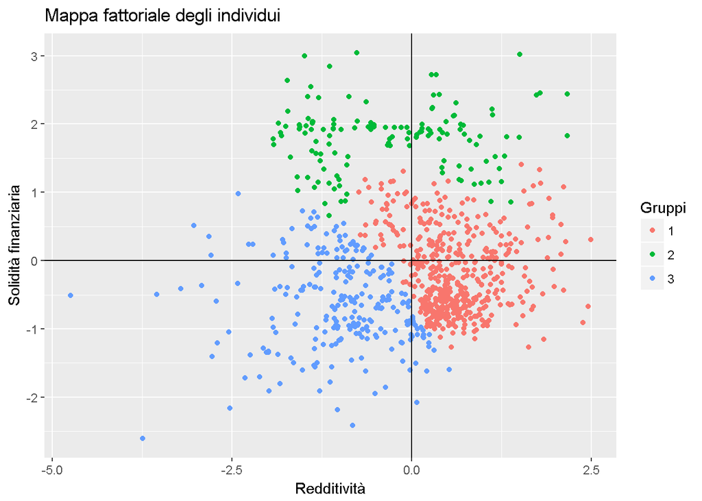

```r
      ggplot(data=dati_finali)+
      geom_point(mapping = aes(x=RC1,y=RC2,color=hclus.label))+
      geom_hline(yintercept = 0)+
      geom_vline(xintercept = 0)+
      xlab("Redditività")+
      ylab("Solidità finanziaria")+
      labs(title = "Mappa fattoriale degli individui",color = "Gruppi")
```

##Ipotesi con altro punto di cut off cioè 7 gruppi Scelgo 7 gruppi

```r
dati_finali$hclus.label_1 <- assignCluster(model.matrix(~-1 + RC1+RC2, dati_finali), dati_finali, cutree(Hc_dati, k = 7))
```

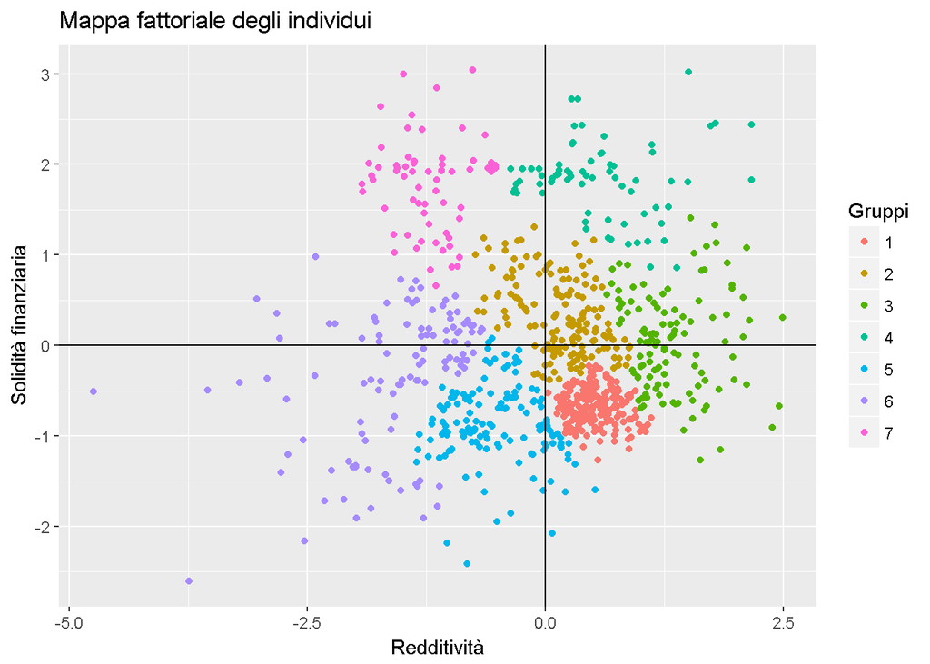

```r
      ggplot(data=dati_finali)+
      geom_point(mapping = aes(x=RC1,y=RC2,color=hclus.label_1))+
      geom_hline(yintercept = 0)+
      geom_vline(xintercept = 0)+
      xlab("Redditività")+
      ylab("Solidità finanziaria")+
      labs(title = "Mappa fattoriale degli individui",color = "Gruppi")
```

## Cerco di dare un significato a questi gruppi tramite variabili a mia disposizione

# variabili territoriali

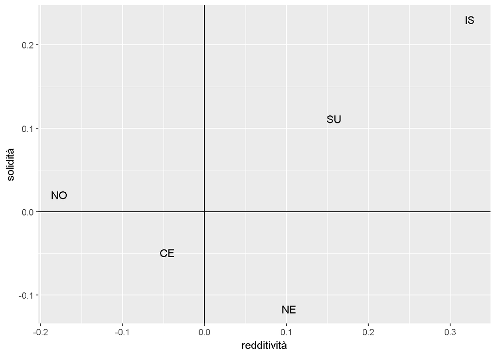

```r
data_macro <- dati_finali %>%
             group_by(Macroregione_NUTS) %>%
             summarise(redditività=mean(RC1),solidità = mean(RC2),count=n(),mean(N_partecipate))


a<-ggplot(data=data_macro,aes(x=redditività,y=solidità,label=Macroregione_NUTS))+
           geom_hline(yintercept = 0)+
           geom_vline(xintercept = 0)

a + geom_text()
```

```r
data_macro
```

```
## # A tibble: 5 x 5
##   Macroregione_NUTS redditività solidità count `mean(N_partecipate)`
##   <chr>                   <dbl>    <dbl> <int>                 <dbl>
## 1 CE                    -0.0455  -0.0489   165                0.0909
## 2 IS                     0.324    0.230     60                0.0667
## 3 NE                     0.103   -0.117    221                0.0452
## 4 NO                    -0.178    0.0204   306                0.176
## 5 SU                     0.158    0.111    124                0.169
```

Sembra che le aziende nelle regioni del sud italia e isole possano identificarsi come i gruppi piu performanti

Dal grafico si evince che ciò è vero ma non descrive comunque i gruppi individuati.

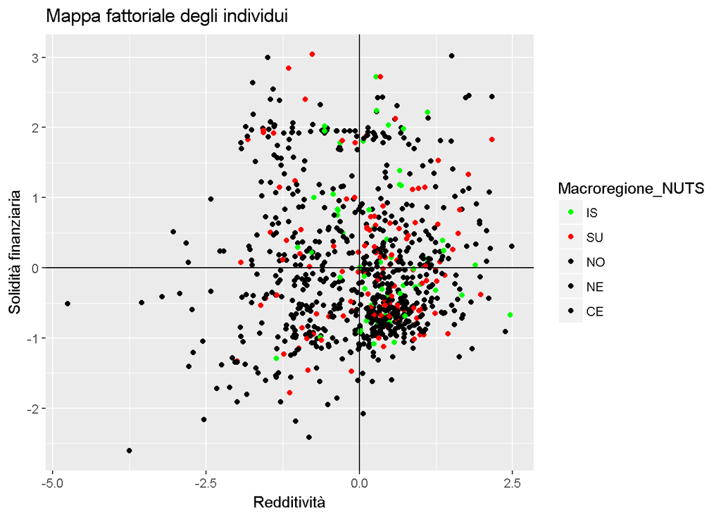

```r
sp <- ggplot(data=dati_finali)+
      geom_point(mapping = aes(x=RC1,y=RC2,color=Macroregione_NUTS))+
      geom_hline(yintercept = 0)+
      geom_vline(xintercept = 0)+
      xlab("Redditività")+
      ylab("Solidità finanziaria")+
      labs(title = "Mappa fattoriale degli individui",color="Macroregione_NUTS" )

sp + scale_color_manual(breaks = c("IS", "SU", "NO","NE","CE"),
                        values=c("black", "green","black","black","red"))
```

Provo 3 macro regioni

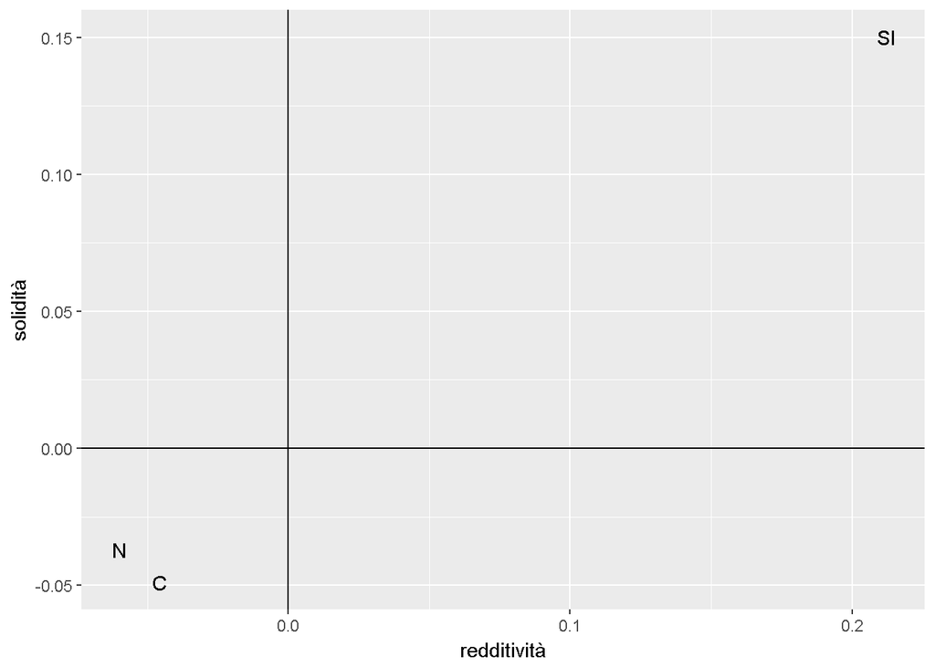

```r
data_macro_3 <- dati_finali %>%
             group_by(Macroregione_SupCor) %>%
             summarise(redditività=mean(RC1),solidità = mean(RC2),count=n(),mean(N_partecipate))


a_3<-ggplot(data=data_macro_3,aes(x=redditività,y=solidità,label=Macroregione_SupCor))+
           geom_hline(yintercept = 0)+
           geom_vline(xintercept = 0)

a_3 + geom_text()
```

```r
data_macro_3
```

```
## # A tibble: 3 x 5
##   Macroregione_SupCor redditività solidità count `mean(N_partecipate)`
##   <chr>                     <dbl>    <dbl> <int>                 <dbl>
## 1 C                       -0.0455  -0.0489   165                0.0909
## 2 N                       -0.0598  -0.0371   527                0.121
## 3 SI                       0.212    0.150    184                0.136
```

Si evince anche qui che il sud è più performate ma con numerosità più bassa è necessario capire se magari tali distinzioni geografiche determino i gruppi ottenunuti

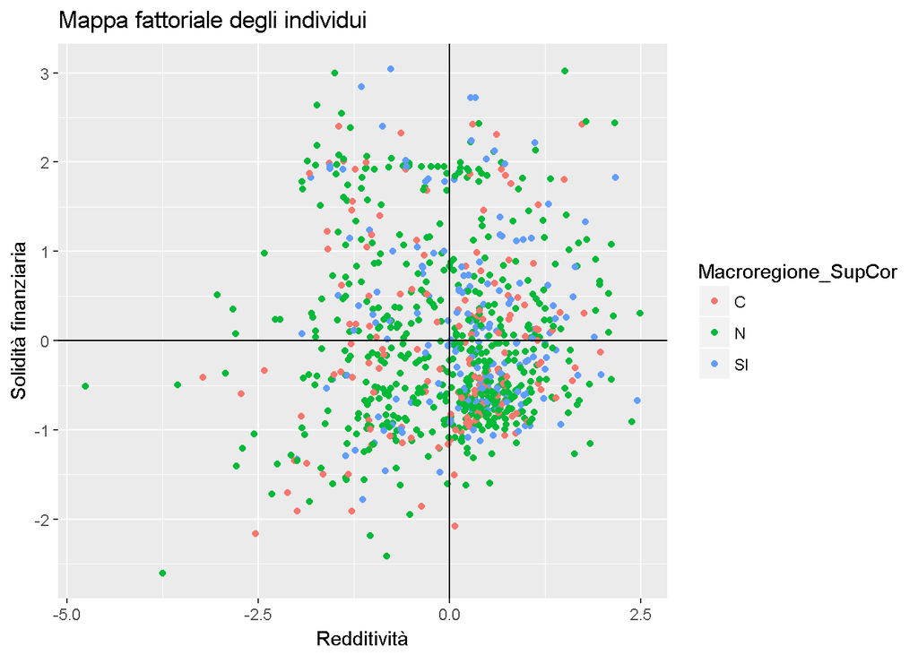

```r
     ggplot(data=dati_finali)+
      geom_point(mapping = aes(x=RC1,y=RC2,color=Macroregione_SupCor ))+
      geom_hline(yintercept = 0)+
      geom_vline(xintercept = 0)+
      xlab("Redditività")+
      ylab("Solidità finanziaria")+
      labs(title = "Mappa fattoriale degli individui",color="Macroregione_SupCor" )
```

Anche in questo caso la distizione geografica non ci permette di definire chiaramente dei gruppi

# Analizzo influenza partecipate

```r
no_partecipate <- dati_finali %>%
                  filter(N_partecipate>0)
data_macro_3_1 <-no_partecipate %>%
             group_by(Macroregione_SupCor) %>%
             summarise(redditività=mean(RC1),solidità=mean(RC2),
                       count=n(),mean(N_partecipate),mean(Dipendenti))

data_macro_3_1
```

```
## # A tibble: 3 x 6
##   Macroregione_SupCor redditività solidità count `mean(N_partecipate)`
##   <chr>                     <dbl>    <dbl> <int>                 <dbl>
## 1 C                       -0.0535  -0.218     12                  1.25
## 2 N                        0.233   -0.0714    36                  1.78
## 3 SI                       0.493   -0.355     19                  1.32
## # ... with 1 more variable: `mean(Dipendenti)` <dbl>
```

partecipate non sono utili a spiegare il successo del sud-isole italia Per provincia per il sud per capire meglio il fenomeno

```r
data_prov_1 <- dati_finali %>%
              filter(Macroregione_NUTS==c("IS","SU"))
data_prov <- data_prov_1 %>%
             group_by(Sede_provincia) %>%
             summarise(redditività=mean(RC1),solidità = mean(RC2),count=n())

data_prov <- data_prov %>%
            arrange(desc(count))
data_prov
```

```
## # A tibble: 24 x 4
##    Sede_provincia redditività solidità count
##    <chr>                <dbl>    <dbl> <int>
##  1 Napoli             0.251   -0.0508     18
##  2 Catania            0.591   -0.236      10
##  3 Cagliari          -0.00767  0.00668     7
##  4 Salerno            0.264    0.785       7
##  5 Bari               0.187    0.206       6
##  6 Cosenza           -0.281    0.134       6
##  7 Palermo            0.0886   0.549       6
##  8 Brindisi           0.950   -0.581       3
##  9 Caserta            0.0157  -0.527       3
## 10 L'Aquila          -0.362    1.20        3
## # ... with 14 more rows
```

Noto che le aziende si concentrano su Napoli e Catania

## Indago se anno creazione influenza

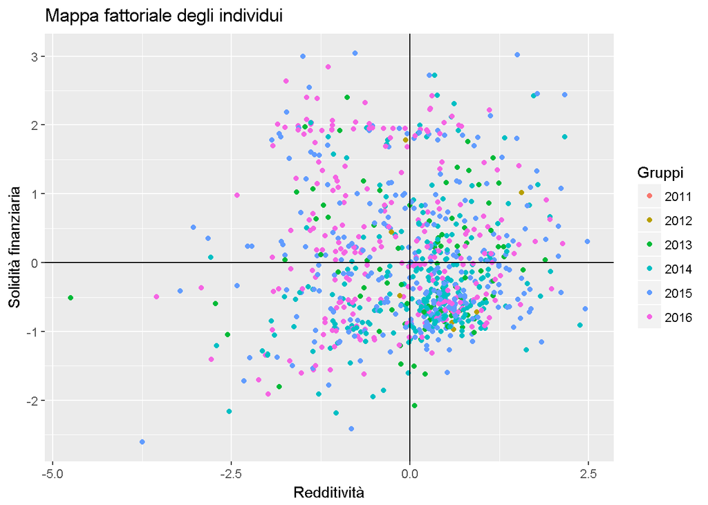

```r
ggplot(data=dati_finali)+
      geom_point(mapping = aes(x=RC1,y=RC2,color=Anno_c))+
      geom_hline(yintercept = 0)+
      geom_vline(xintercept = 0)+
      xlab("Redditività")+
      ylab("Solidità finanziaria")+
      labs(title = "Mappa fattoriale degli individui",color = "Gruppi")
```

Sembra che influisca quindi è necessario un ulteriore analisi

```r
dati_finali$Anno_c_n <- as.numeric(dati_finali$Anno_c)
dati_finali_4 <- mutate(dati_finali, anni_attivita = abs(Anno_c_n-2016))
```

```r
data_anno <- dati_finali_4 %>%
             group_by(anni_attivita) %>%
             summarise(redditività=mean(RC1),solidità = mean(RC2))
```

Solidità finanziaria

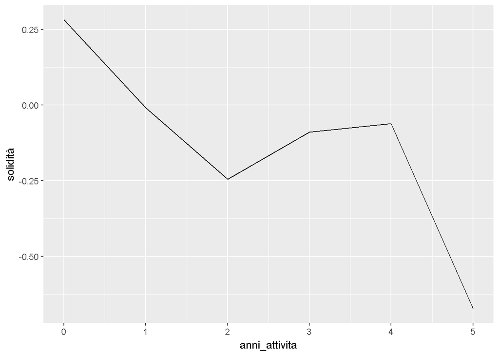

```r
ggplot(data=data_anno)+
      geom_line(mapping=aes(x=anni_attivita,y=solidità))
```

Redditività

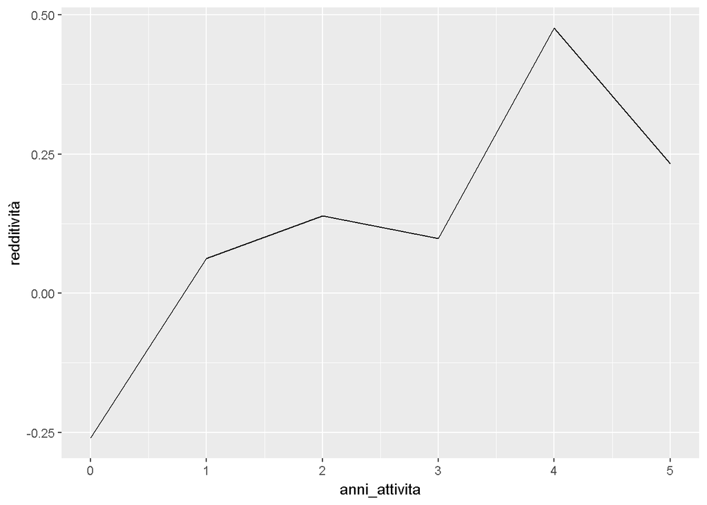

```r
ggplot(data=data_anno)+
      geom_line(mapping=aes(x=anni_attivita,y=redditività))
```

aggrego anni per vedere se tali definiscono i gruppi

```r
data_anno_1 <- dati_finali_4 %>%
             group_by(anni_attivita) %>%
             summarise(redditività=mean(RC1),solidità = mean(RC2),count=n())
data_anno_1
```

```
## # A tibble: 6 x 4
##   anni_attivita redditività solidità count
##           <dbl>       <dbl>    <dbl> <int>
## 1            0.     -0.260   0.282     247
## 2            1.      0.0628 -0.00865   291
## 3            2.      0.139  -0.245     235
## 4            3.      0.0982 -0.0893     94
## 5            4.      0.476  -0.0607      8
## 6            5.      0.233  -0.673       1
```

é necessario scartare 5 anno con una sola osservazione

```r
data_anno_2 <- data_anno_1 %>%
               filter(anni_attivita!=5)
```

grafici

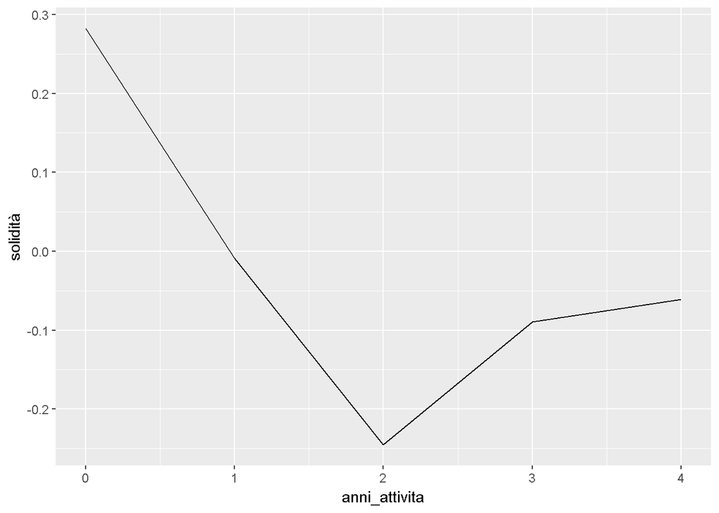

```r
ggplot(data=data_anno_2)+
      geom_line(mapping=aes(x=anni_attivita,y=solidità))
```

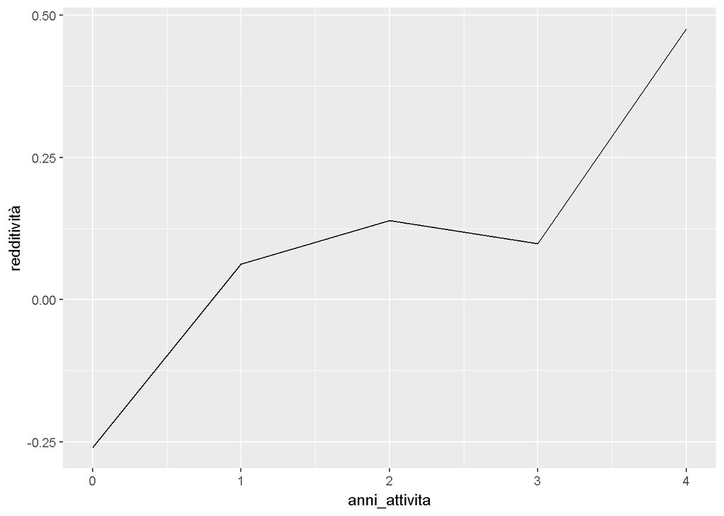

```r
ggplot(data=data_anno_2)+
      geom_line(mapping=aes(x=anni_attivita,y=redditività))
```

Visto l’andamento per individuare i gruppi prendo 3 gruppi individuati con anno 0 anno 1 2 e anno 3 4

```r
dati_finali_5 <- dati_finali_4 %>%
                 filter(anni_attivita!=5)
dati_finali_5$anni_attivita <- as.factor(dati_finali_5$anni_attivita)
dati_finali_5 <- dati_finali_5 %>% mutate(D_anni=fct_recode(dati_finali_5$anni_attivita,
                                   "Start"   = "0",
                                   "Mid"  = "1",
                                   "Mid"  = "2",
                                   "End"= "3",
                                   "End"= "4"))
```

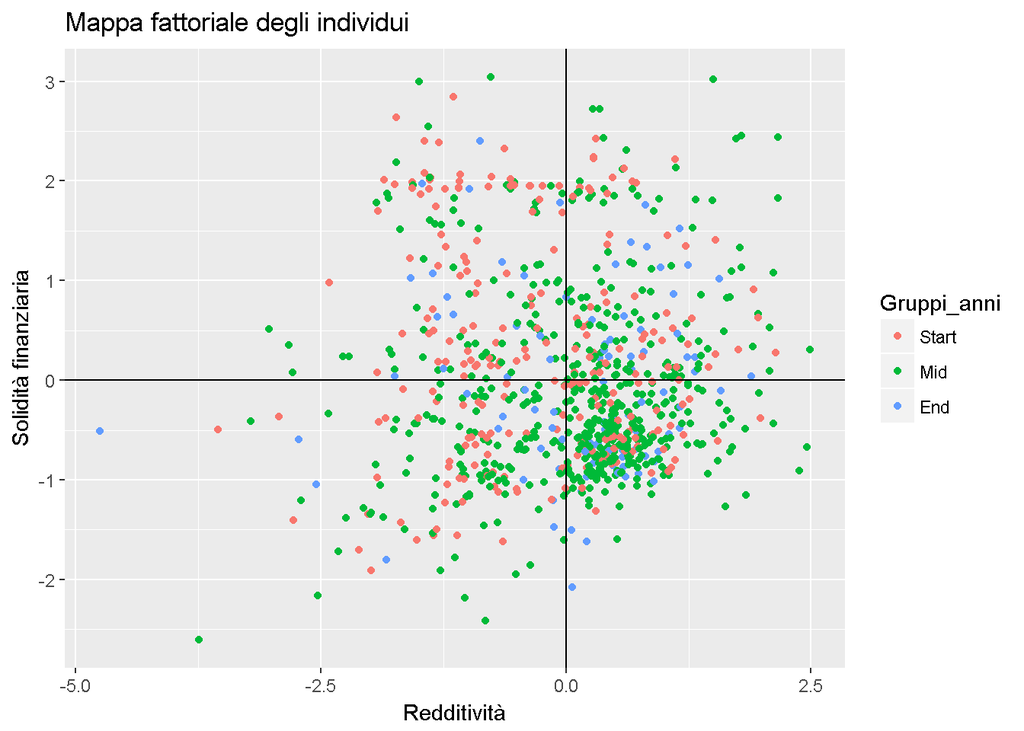

```r
ggplot(data=dati_finali_5)+
      geom_point(mapping = aes(x=RC1,y=RC2,color=D_anni))+
      geom_hline(yintercept = 0)+
      geom_vline(xintercept = 0)+
      xlab("Redditività")+
      ylab("Solidità finanziaria")+
      labs(title = "Mappa fattoriale degli individui",color = "Gruppi_anni")
```

Anni anche raggruppati non ci permettono di evidenziari gruppi

```r
data_anno_3 <- dati_finali_5 %>%
             group_by(D_anni) %>%
             summarise(redditività=mean(RC1),solidità = mean(RC2),count=n())
data_anno_3
```

```
## # A tibble: 3 x 4
##   D_anni redditività solidità count
##   <fct>        <dbl>    <dbl> <int>
## 1 Start      -0.260    0.282    247
## 2 Mid         0.0968  -0.114    526
## 3 End         0.128   -0.0871   102
```

# Analisi rispetto a i requisiti per diventare start-up

```r
data_sud <- dati_finali %>%
            filter(Macroregione_NUTS==c("SU","IS"))
data_sud_1 <- data_sud %>%
             select(req_1,req_2,req_3,Nome)
table(data_sud_1$req_1)
```

```
##
## NO SI
## 27 66
```

```r
table(data_sud_1$req_2)
```

```
##
## NO SI
## 66 27
```

```r
table(data_sud_1$req_3)
```

```
##
## NO SI
## 80 13
```

Quindi si evidenzia che le aziende del sud non producono brevetti o licenze.(no req3) Che il personale non è altamente formato( no req2) Unico requisito che hanno è gli investimenti in ricerca e sviluppo(req1) Quindi è una truffa?!

```r
data_nord <- dati_finali %>%
            filter(Macroregione_NUTS==c("NO","NE","CE"))
data_nord_1 <- data_nord %>%
             select(req_1,req_2,req_3,Nome)
table(data_nord_1$req_1)
```

```
##
##  NO  SI
##  69 154
```

```r
table(data_nord_1$req_2)
```

```
##
##  NO  SI
## 174  49
```

```r
table(data_nord_1$req_3)
```

```
##
##  NO  SI
## 182  41
```

Si evidenzia lo stesso trend in tutta italia

## Analisi delle aziende in liquidazione

creo dummy per fallimento o meno

```r
dati_finali$fall <- as.numeric(dati_finali$Stato_giuridico  =="Attiva")
dati_finali$fall <- as.factor(dati_finali$fall)
dati_finali %>%
    count(fall)
```

```
## # A tibble: 2 x 2
##   fall      n
##   <fct> <int>
## 1 0        17
## 2 1       859
```

Ci sono 17 aziende in liquidazione

Grafico

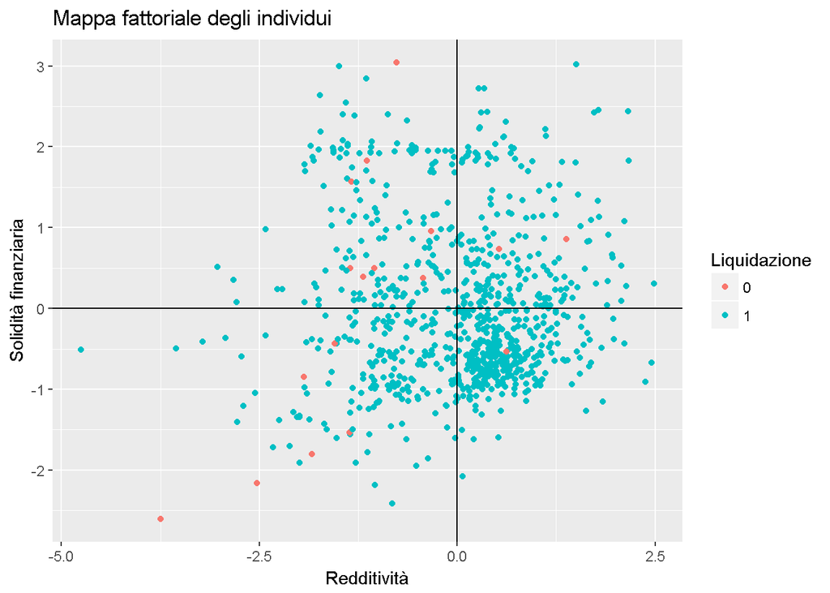

```r
ggplot(data=dati_finali)+
      geom_point(mapping = aes(x=RC1,y=RC2,color=fall))+
      geom_hline(yintercept = 0)+
      geom_vline(xintercept = 0)+
      xlab("Redditività")+
      ylab("Solidità finanziaria")+
      labs(title = "Mappa fattoriale degli individui",color = "Liquidazione")
```

#Analizzo aziende in liquidazione per individuare metodi di stratificazione per campionare le attive

```r
dati_finali_fall_1 <- dati_finali %>%
                      filter(fall==0)
str(dati_finali_fall_1)
```

```
## 'data.frame':    17 obs. of  37 variables:
##  $ Nome               : chr  "MADAI ITALIA S.R.L. IN LIQUIDAZIONE" "EXORDIUM S.R.L.- IN LIQUIDAZIONE" "RESTART LABS - SOCIETA'A RESPONSABILITA' LIMITATA SEMPLIFICATA" "LUMOS MEDICA S.R.L. IN LIQUIDAZIONE" ...
##  $ Anno               : chr  "2016" "2016" "2016" "2016" ...
##  $ Mese               : chr  "12" "12" "12" "12" ...
##  $ Giorno             : chr  "31" "31" "31" "31" ...
##  $ ROA                : num  -266.97 -43.98 -4.52 6.71 -149.53 ...
##  $ EBITDAmarg         : num  -145.63 -45.3 -2.38 27.96 -118.84 ...
##  $ RotazCapInv        : num  1.75 0.65 1.58 0.57 0.41 0 0 0 0 0 ...
##  $ IndiIndipFin       : num  2.37 30.79 24.14 69.38 -10.51 ...
##  $ IndCorr            : num  1.25 4.9 1.36 2.81 0.42 ...
##  $ Sede_Longitudine   : chr  "9.200088" "11.535543" "15.786931" "11.300152" ...
##  $ Sede_Latitudine    : chr  "45.477044" "45.563543" "37.919944" "44.499758" ...
##  $ Website            : chr  "it.madai.com" "www.cosatiporto.com" "www.restartlabs.it" "www.lumosproject.com" ...
##  $ ATECO_codice       : chr  "620100" "620909" "620100" "620100" ...
##  $ Dipendenti         : num  3 5 0 0 1 0 0 0 0 0 ...
```

[output cut: 23 more lines]

```r
dati_finali_fall_regio <- dati_finali_fall_1 %>%
                          select(Macroregione_NUTS)
table(dati_finali_fall_regio$Macroregione_NUTS)
```

```
##
## CE NE NO SU
##  4  3  7  3
```

Campioniamo allo stesso modo per le attive

```r
dati_finali_fall_0 <- dati_finali %>%
                      filter(fall==1)

dati_finali_fall_0_1<- dati_finali_fall_0 %>%
                      filter(Macroregione_NUTS=="CE")

dati_finali_fall_0_1 <- dati_finali_fall_0_1[sample(nrow(dati_finali_fall_0_1),4),]

dati_finali_fall_0_2<- dati_finali_fall_0 %>%
                      filter(Macroregione_NUTS=="NE")

dati_finali_fall_0_2 <- dati_finali_fall_0_2[sample(nrow(dati_finali_fall_0_2),3),]
dati_finali_fall_0_3<- dati_finali_fall_0 %>%
                      filter(Macroregione_NUTS=="NO")

dati_finali_fall_0_3 <- dati_finali_fall_0_3[sample(nrow(dati_finali_fall_0_3),7),]

dati_finali_fall_0_4<- dati_finali_fall_0 %>%
                      filter(Macroregione_NUTS=="SU")

dati_finali_fall_0_4 <- dati_finali_fall_0_4[sample(nrow(dati_finali_fall_0_4),3),]

dati_attive <- rbind(dati_finali_fall_0_1,dati_finali_fall_0_2,dati_finali_fall_0_3,
                     dati_finali_fall_0_4)
```

Ora unisco attive campionate e in liquidazione

```r
dati_log <- rbind(dati_attive,dati_finali_fall_1)
```

Visualizzo il sample creato

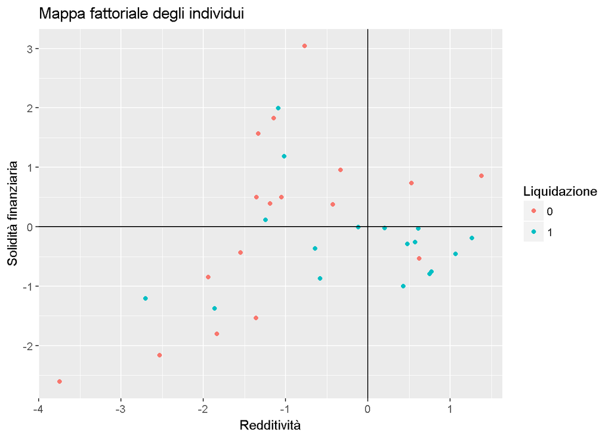

```r
ggplot(data=dati_log)+
      geom_point(mapping = aes(x=RC1,y=RC2,color=fall))+
      geom_hline(yintercept = 0)+
      geom_vline(xintercept = 0)+
      xlab("Redditività")+
      ylab("Solidità finanziaria")+
      labs(title = "Mappa fattoriale degli individui",color = "Liquidazione")
```

##Tento di creare un modello per la previsione delle insolvenze

Modello logistico

```r
library(MASS)

modello1 <- glm(fall ~ RC1,
                family=binomial(link='logit'),data=dati_log)
summary(modello1)
```

```
##
## Call:
## glm(formula = fall ~ RC1, family = binomial(link = "logit"),
##     data = dati_log)
##
## Deviance Residuals:
##     Min       1Q   Median       3Q      Max
## -1.7744  -1.0056   0.1147   0.9407   1.8083
##
## Coefficients:
##             Estimate Std. Error z value Pr(>|z|)
## (Intercept)   0.4097     0.4184   0.979   0.3275
## RC1           0.6757     0.3384   1.997   0.0458 *
## ---
## Signif. codes:  0 '***' 0.001 '**' 0.01 '*' 0.05 '.' 0.1 ' ' 1
##
## (Dispersion parameter for binomial family taken to be 1)
##
##     Null deviance: 47.134  on 33  degrees of freedom
## Residual deviance: 42.397  on 32  degrees of freedom
## AIC: 46.397
##
## Number of Fisher Scoring iterations: 4
```

```r
previsione1 <- predict(modello1,dati_log)
previsione1 <- ifelse(previsione1>0.5,1,0)
table(previsione1,dati_log$fall)
```

```
##
## previsione1  0  1
##           0 14  8
##           1  3  9
```

## Guardo tra fallite per case study

```r
dati_fallite <- dati_finali_fall_1
dati_fallite %>%
   arrange(RC1,RC2)
```

```
##                                                               Nome Anno
## 1                              MADAI ITALIA S.R.L. IN LIQUIDAZIONE 2016
## 2                                  PRO.GEST S.R.L. IN LIQUIDAZIONE 2016
## 3  PRENDOPOSTA SOCIETA' A RESPONSABILITA' LIMITATA IN LIQUIDAZIONE 2016
## 4                             SHARE THE WAY S.R.L. IN LIQUIDAZIONE 2016
## 5                                  LIFEPAGE S.R.L. IN LIQUIDAZIONE 2016
## 6                                  WE DREAM S.R.L. IN LIQUIDAZIONE 2016
## 7                               LITTLETHUMB S.R.L. IN LIQUIDAZIONE 2016
## 8                                      MEMOREX SRL IN LIQUIDAZIONE 2016
## 9                             DRONE ACADEMY S.R.L. IN LIQUIDAZIONE 2016
## 10                            JOINBOOKING S.R.L. - IN LIQUIDAZIONE 2016
## 11                               WANDERLOST S.R.L. IN LIQUIDAZIONE 2016
## 12                                 MY WORLD S.R.L. IN LIQUIDAZIONE 2016
## 13                                EXORDIUM S.R.L.- IN LIQUIDAZIONE 2016
## 14                    WEEVIA - SOCIETA' A RESPONSABILITA' LIMITATA 2016
```

[output cut: 129 more lines]

```r
dati_fallite$Website
```

```
##  [1] "it.madai.com"            "www.cosatiporto.com"
##  [3] "www.restartlabs.it"      "www.lumosproject.com"
##  [5] "www.pro-gestsrl.it"      "www.wanderlo.st"
##  [7] "www.memorex-srl.eu"      "www.prendoposta.it"
##  [9] "www.weevia.com"          "www.droneaccademysrl.it"
## [11] "www.littlethumb.it"      "www.wedream.biz"
## [13] "www.everyride.it"        "www.life-page.eu"
## [15] "sharetheway.it"          "www.joinbooking.com"
## [17] "www.makeyourbo.it"
```